# Simple Linear Regression

DACSS 603 Homework 2

Rhowena Vespa  
2/25/2022

```r
library(distill)
library(dplyr)
library(tidyverse)
library(knitr)
library(alr4)
library(ggplot2)
library(smss)
```

## Question 1

(Problem 1.1 in ALR)

United Nations (Data file: UN11) The data in the file UN11 contains several variables, including ppgdp, the gross national product per person in U.S. dollars, and fertility, the birth rate per 1000 females, both from the year 2009. The data are for 199 localities, mostly UN member countries, but also other areas such as Hong Kong that are not independent countries. The data were collected from the United Nations (2011). We will study the dependence of fertility on ppgdp.

```r
data("UN11") # load the UN11 data
UN11 <- UN11 %>%
  select(c(fertility,ppgdp)) # select the two variables to use
dim(UN11)
```

```
[1] 199   2
```

```r
kable(head(UN11), format = "markdown", digits = 10, caption = "**Dependence of Fertility on ppgdp**")
```

Table 1: **Dependence of Fertility on ppgdp**

|  | fertility | ppgdp |
| --- | --- | --- |
| Afghanistan | 5.968 | 499.0 |
| Albania | 1.525 | 3677.2 |
| Algeria | 2.142 | 4473.0 |
| Angola | 5.135 | 4321.9 |
| Anguilla | 2.000 | 13750.1 |
| Argentina | 2.172 | 9162.1 |

**1.1.1. Identify the predictor and the response.**

Predictor is ppgdp, response is fertility.

**1.1.2 Draw the scatterplot of fertility on the vertical axis versus ppgdp on the horizontal axis and summarize the information in this graph. Does a straight-line mean function seem to be plausible for a summary of this graph?**

See Figure 1.1 below. From this graph, a straight line mean function DOES NOT SEEM PLAUSIBLE for a summary of this graph. It looks like there is a negative correlation between ppgdp and fertility but we will need the lm function to visualize it.

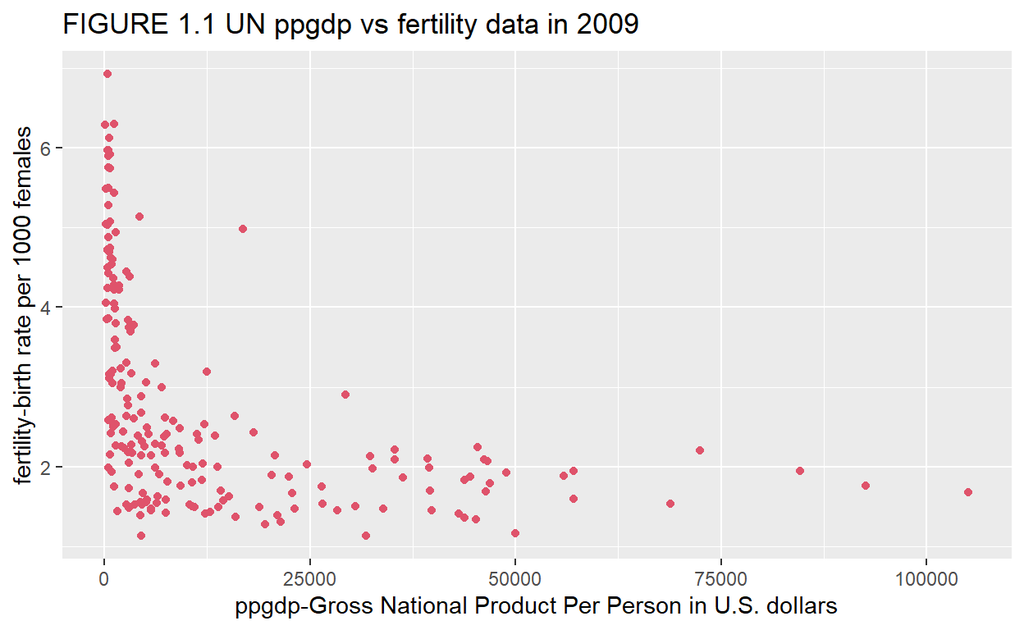

```r
ggplot(UN11, aes(x = ppgdp, y = fertility)) +
    geom_point(color=2) +
    labs(x="ppgdp-Gross National Product Per Person in U.S. dollars", y="fertility-birth rate per 1000 females", title = "FIGURE 1.1 UN ppgdp vs fertility data in 2009")
```

**1.1.3 Draw the scatterplot of log(fertility) versus log(ppgdp) using natural logarithms. Does the simple linear regression model seem plausible for a summary of this graph? If you use a different base of logarithms, the shape of the graph won’t change, but the values on the axes will change.**

See Figure 1.2 below. Yes, a simple linear regression model looks more plausible on this graph. Using the log function produced a graph with a more linear relationship between ppgdp and fertility.

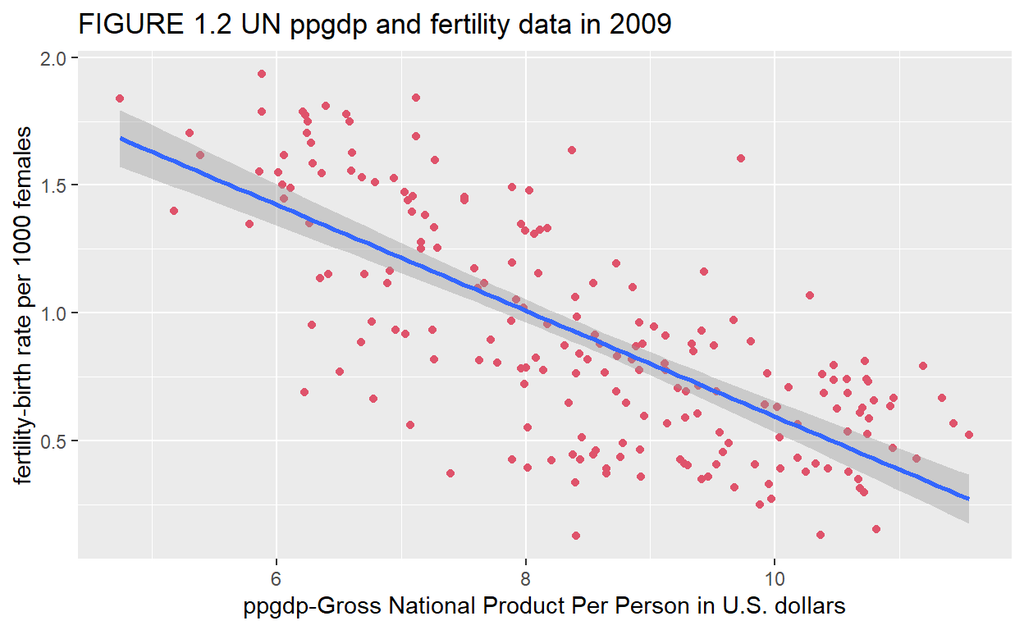

```r
ggplot(UN11, aes(x = log(ppgdp), y = log(fertility))) +
    geom_point(color=2) +
    geom_smooth(method = "lm") +
    labs(x="ppgdp-Gross National Product Per Person in U.S. dollars", y="fertility-birth rate per 1000 females", title = "FIGURE 1.2 UN ppgdp and fertility data in 2009")
```

## Question 2

(Problem 9.47 in SMSS)

Annual income, in dollars, is an explanatory variable in a regression analysis. For a British version of the report on the analysis, all responses are converted to British pounds sterling (1 pound equals about 1.33 dollars, as of 2016).

**(b) How, if at all, does the correlation change?**

No, a change in units on the explanatory variables from US Dollar to British pounds will not result in a correlation change. Correlation DOES NOT depend on the variable’s units.

## Question 3

(Problem 1.5 in ALR)

Water runoff in the Sierras (Data file: water) Can Southern California’s water supply in future years be predicted from past data? One factor affecting water availability is stream runoff. If runoff could be predicted, engineers, planners, and policy makers could do their jobs more efficiently. The data file contains 43 years’ worth of precipitation measurements taken at six sites in the Sierra Nevada mountains (labeled APMAM, APSAB, APSLAKE, OPBPC, OPRC, and OPSLAKE) and stream runoff volume at a site near Bishop, California, labeled BSAAM. Draw the scatterplot matrix for these data and summarize the information available from these plots.

```r
data("water") # load the water data
dim(water)
```

```
[1] 43  8
```

```r
kable(head(water), format = "markdown", digits = 10, caption = "**Water runoff in the Sierras**")
```

Table 2: **Water runoff in the Sierras**

| Year | APMAM | APSAB | APSLAKE | OPBPC | OPRC | OPSLAKE | BSAAM |
| --- | --- | --- | --- | --- | --- | --- | --- |
| 1948 | 9.13 | 3.58 | 3.91 | 4.10 | 7.43 | 6.47 | 54235 |
| 1949 | 5.28 | 4.82 | 5.20 | 7.55 | 11.11 | 10.26 | 67567 |
| 1950 | 4.20 | 3.77 | 3.67 | 9.52 | 12.20 | 11.35 | 66161 |
| 1951 | 4.60 | 4.46 | 3.93 | 11.14 | 15.15 | 11.13 | 68094 |
| 1952 | 7.15 | 4.99 | 4.88 | 16.34 | 20.05 | 22.81 | 107080 |
| 1953 | 9.70 | 5.65 | 4.91 | 8.88 | 8.15 | 7.41 | 67594 |

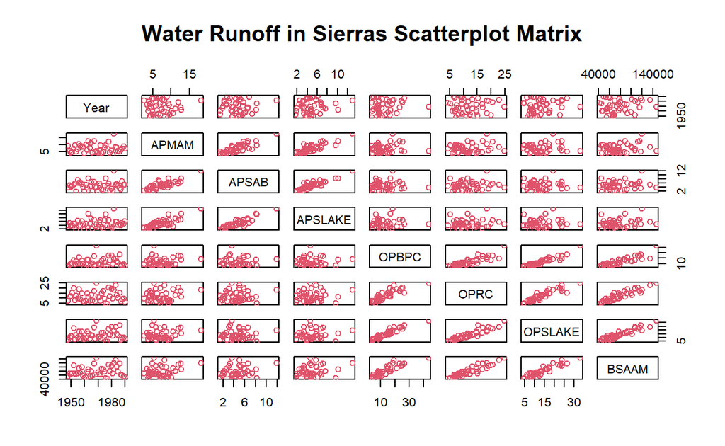

```r
pairs(water,col = 2, main = "Water Runoff in Sierras Scatterplot Matrix")
```

```r
water1 <-lm(BSAAM ~ APMAM + APSAB + APSLAKE + OPBPC + OPRC + OPSLAKE, data = water)
summary(water1)
```

```
Call:
lm(formula = BSAAM ~ APMAM + APSAB + APSLAKE + OPBPC + OPRC +
    OPSLAKE, data = water)

Residuals:
   Min     1Q Median     3Q    Max
-12690  -4936  -1424   4173  18542

Coefficients:
            Estimate Std. Error t value Pr(>|t|)
(Intercept) 15944.67    4099.80   3.889 0.000416 ***
APMAM         -12.77     708.89  -0.018 0.985725
APSAB        -664.41    1522.89  -0.436 0.665237
APSLAKE      2270.68    1341.29   1.693 0.099112 .
OPBPC          69.70     461.69   0.151 0.880839
OPRC         1916.45     641.36   2.988 0.005031 **
OPSLAKE      2211.58     752.69   2.938 0.005729 **
---
Signif. codes:  0 '***' 0.001 '**' 0.01 '*' 0.05 '.' 0.1 ' ' 1

Residual standard error: 7557 on 36 degrees of freedom
Multiple R-squared:  0.9248,    Adjusted R-squared:  0.9123
F-statistic: 73.82 on 6 and 36 DF,  p-value: < 2.2e-16
```

**ANALYSIS:**

On residuals, although there is a big disparity between the min and max (-12690 and 18542), which can be possible outliers, I think the data is relatively balanced because the 1Q and 3Q (-4936 and 4173) are close in values.

On coefficients, sites OPRC and OPSLAKE has statistically significant values of Pr(>|t|) < 0.05, indicating that these two locations’ precipitation measurements are significant to BASAAM stream runoff volume.

Multiple R-squared 0.9248 and adjusted R-squared 0.9123 are relatively close, suggesting model in not over-fitted. An adjusted R-squared of 0.9123 indicates a good fit for the model.

Lastly, with a p-value: < 2.2e-16, we can conclude that this model is statistically significant. This model can be used to predict runoff so engineers, planners, and policy makers could do their jobs more efficiently.

## Question 4

(Problem 1.6 in ALR - slightly modified)

```r
data(Rateprof)
Rateprof <- Rateprof %>%
  select(c(quality,helpfulness,clarity,easiness,raterInterest)) # select the five variables to use
dim(Rateprof)
```

```
[1] 366   5
```

```r
kable(head(Rateprof), format = "markdown", digits = 10, col.names = c('Quality','Helpfulness','Clarity', 'Easiness', 'Rater Interest'), caption = "**Professor Ratings**")
```

Table 3: **Professor Ratings**

| Quality | Helpfulness | Clarity | Easiness | Rater Interest |
| --- | --- | --- | --- | --- |
| 4.636364 | 4.636364 | 4.636364 | 4.818182 | 3.545455 |
| 4.318182 | 4.545455 | 4.090909 | 4.363636 | 4.000000 |
| 4.790698 | 4.720930 | 4.860465 | 4.604651 | 3.432432 |
| 4.250000 | 4.458333 | 4.041667 | 2.791667 | 3.181818 |
| 4.684211 | 4.684211 | 4.684211 | 4.473684 | 4.214286 |
| 4.233333 | 4.266667 | 4.200000 | 4.533333 | 3.916667 |

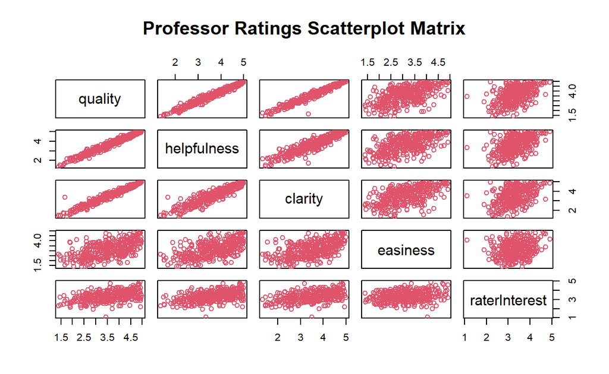

```r
pairs(Rateprof,col = 2, main = "Professor Ratings Scatterplot Matrix")
```

**Provide a brief description of the relationships between the five ratings. (The variables don’t have to be in the same order)**

Based on this scatterplot matrix, we can observe a **very strong linear positive correlation** between: quality and helpfulness, quality and clarity, helpfulness and clarity.

There is **moderate positive linear correlation** between easiness and quality, clarity or helpfulness.

There is **moderate positive linear correlation** between raterinterest and clarity, helpfulness or quality

Easiness and raterinterest have a **weak positive linear association.**

```r
RP <-cor(Rateprof, use = "all.obs",method = c("pearson", "kendall", "spearman"))
kable ((RP), format = "markdown", digits = 10, col.names = c('Quality','Helpfulness','Clarity', 'Easiness', 'Rater Interest'), caption = "**Correlation Matrix**")
```

Table 4: **Correlation Matrix**

|  | Quality | Helpfulness | Clarity | Easiness | Rater Interest |
| --- | --- | --- | --- | --- | --- |
| quality | 1.0000000 | 0.9810314 | 0.9759608 | 0.5651154 | 0.4706688 |
| helpfulness | 0.9810314 | 1.0000000 | 0.9208070 | 0.5635184 | 0.4630321 |
| clarity | 0.9759608 | 0.9208070 | 1.0000000 | 0.5358884 | 0.4611408 |
| easiness | 0.5651154 | 0.5635184 | 0.5358884 | 1.0000000 | 0.2052237 |
| raterInterest | 0.4706688 | 0.4630321 | 0.4611408 | 0.2052237 | 1.0000000 |

## Question 5

(Problem 9.34 in SMSS)

For the student.survey data file in the smss package, conduct regression analyses relating (i) y = political ideology and x = religiosity, (ii) y = high school GPA and x = hours of TV watching.

(You can use ?student.survey in the R console, after loading the package, to see what each variable means.)

```r
data("student.survey") # load the student.survey data
student.survey <- student.survey %>%
  select(c(re,pi,hi,tv)) # select the four variables to use
dim(student.survey)
```

```
[1] 60  4
```

```r
kable(head(student.survey), format = "markdown", digits = 2, col.names = c('Religiosity','Political Ideology','HS GPA', 'Hrs of watching TV'), caption = "**Student Survey Data**")
```

Table 5: **Student Survey Data**

| Religiosity | Political Ideology | HS GPA | Hrs of watching TV |
| --- | --- | --- | --- |
| most weeks | conservative | 2.2 | 3 |
| occasionally | liberal | 2.1 | 15 |
| most weeks | liberal | 3.3 | 0 |
| occasionally | moderate | 3.5 | 5 |
| never | very liberal | 3.1 | 6 |
| occasionally | liberal | 3.5 | 4 |

## A. Graph of Individual Variables and their Relationship

### (i) y = political ideology and x = religiosity

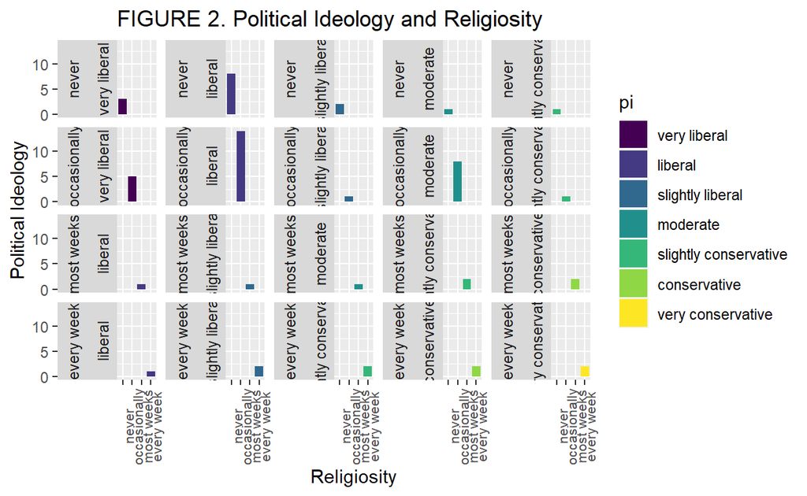

```r
ggplot(student.survey, aes(x=re,ymin = 0, ymax = 30, fill=pi)) +
  geom_bar() +
  labs(x="Religiosity", y="Political Ideology",
  title = "FIGURE 2. Political Ideology and Religiosity") +
  facet_wrap(vars(re,pi),strip.position = "left") +
  theme(axis.text.x = element_text(size = 8, angle = 90))
```

```r
student.survey %>%
    count(pi,re, sort = TRUE) %>%
  kable(head(10), format = "markdown", digits = 10, col.names = c('Political Ideology','Religiosity','Number of Students'), caption = "**Political Ideology and Religiosity Matrix Count**")
```

Table 6: **Political Ideology and Religiosity Matrix Count**

|  | Political Ideology | Religiosity | Number of Students |
| --- | --- | --- | --- |
| 1 | liberal | occasionally | 14 |
| 2 | liberal | never | 8 |
| 3 | moderate | occasionally | 8 |
| 4 | very liberal | occasionally | 5 |
| 5 | very liberal | never | 3 |
| 6 | slightly liberal | never | 2 |
| 7 | slightly liberal | every week | 2 |
| 8 | slightly conservative | most weeks | 2 |
| 9 | slightly conservative | every week | 2 |
| 10 | conservative | most weeks | 2 |
| 11 | conservative | every week | 2 |
| 12 | very conservative | every week | 2 |
| 13 | liberal | most weeks | 1 |
| 14 | liberal | every week | 1 |
| 15 | slightly liberal | occasionally | 1 |
| 16 | slightly liberal | most weeks | 1 |
| 17 | moderate | never | 1 |
| 18 | moderate | most weeks | 1 |
| 19 | slightly conservative | never | 1 |
| 20 | slightly conservative | occasionally | 1 |

### (ii) y = high school GPA and x = hours of TV watching.

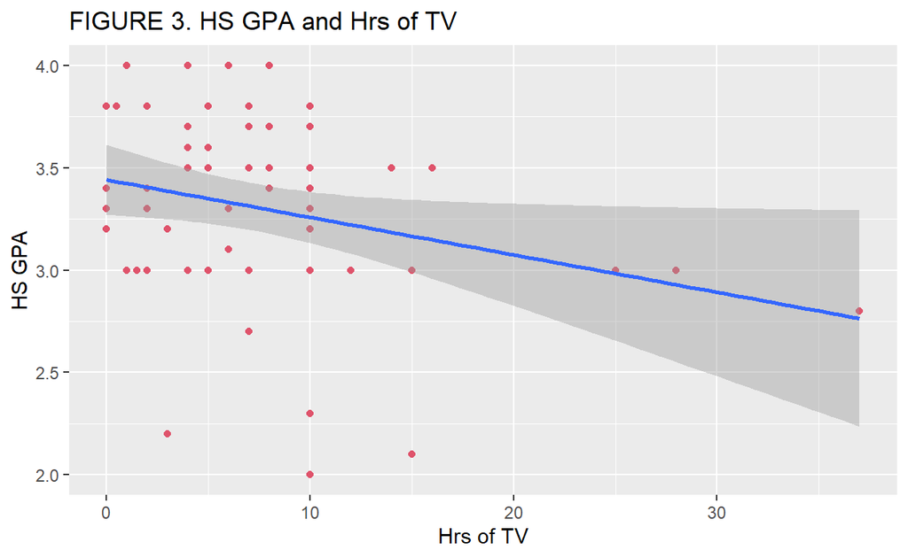

```r
ggplot(student.survey, aes(x = tv, y = hi)) +
    geom_point(color=2) +
    geom_smooth(method = "lm") +
    labs(x="Hrs of TV", y="HS GPA", title = "FIGURE 3. HS GPA and Hrs of TV")
```

## B. Interpret Descriptive Statistics of Variables and their Relationship.

```r
summary(student.survey)
```

```
            re                         pi           hi
 never       :15   very liberal         : 8   Min.   :2.000
 occasionally:29   liberal              :24   1st Qu.:3.000
 most weeks  : 7   slightly liberal     : 6   Median :3.350
 every week  : 9   moderate             :10   Mean   :3.308
                   slightly conservative: 6   3rd Qu.:3.625
                   conservative         : 4   Max.   :4.000
                   very conservative    : 2
       tv
 Min.   : 0.000
 1st Qu.: 3.000
 Median : 6.000
 Mean   : 7.267
 3rd Qu.:10.000
 Max.   :37.000
```

**INTERPRETATION:**

**Religiosity:** Mode is Occasionally (count: 29) **Political Ideology:**Mode is liberal (count:24). Based on this, a visualization of re vs pi (see figure 2) showed that this population had mostly occasional religiosity and liberal ideology as the mode.

## C. Summarize and Interpret results of Inferential Analyses

```r
SS.glm.fit <- glm(re ~ pi, data = student.survey, family = binomial)
summary(SS.glm.fit)
```

```
Call:
glm(formula = re ~ pi, family = binomial, data = student.survey)

Deviance Residuals:
    Min       1Q   Median       3Q      Max
-2.1460  -0.3500   0.5314   0.9005   0.9695

Coefficients:
             Estimate Std. Error z value Pr(>|z|)
(Intercept)    5.8337   489.4505   0.012    0.990
pi.L          16.2199  1753.3896   0.009    0.993
pi.Q           8.1491  1526.1299   0.005    0.996
pi.C          -0.2996  1398.7211   0.000    1.000
pi^4          -4.6817  1304.7376  -0.004    0.997
pi^5          -5.0032   915.6782  -0.005    0.996
pi^6          -3.3188   401.1467  -0.008    0.993

(Dispersion parameter for binomial family taken to be 1)

    Null deviance: 67.480  on 59  degrees of freedom
Residual deviance: 60.684  on 53  degrees of freedom
AIC: 74.684

Number of Fisher Scoring iterations: 16
```

**INTERPRETATION**

**Based on all the p-values, we fail to reject the null hypothesis and conclude that there is no association between religiosity and political ideology.**

### (ii) LINEAR REGRESSION: y = high school GPA and x = hours of TV watching

```r
student.surveyii <-lm(hi ~ tv, data = student.survey)
summary(student.surveyii)
```

```
Call:
lm(formula = hi ~ tv, data = student.survey)

Residuals:
    Min      1Q  Median      3Q     Max
-1.2583 -0.2456  0.0417  0.3368  0.7051

Coefficients:
             Estimate Std. Error t value Pr(>|t|)
(Intercept)  3.441353   0.085345  40.323   <2e-16 ***
tv          -0.018305   0.008658  -2.114   0.0388 *
---
Signif. codes:  0 '***' 0.001 '**' 0.01 '*' 0.05 '.' 0.1 ' ' 1

Residual standard error: 0.4467 on 58 degrees of freedom
Multiple R-squared:  0.07156,   Adjusted R-squared:  0.05555
F-statistic: 4.471 on 1 and 58 DF,  p-value: 0.03879
```

```r
student.survey1 <- student.survey %>%
  select(c(hi,tv))
cor(student.survey1)
```

```
           hi         tv
hi  1.0000000 -0.2675115
tv -0.2675115  1.0000000
```

**INTERPRETATION**

Based on the p-value 0.0388, we reject the null hypothesis. Therefore, we can conclude that there is statistically significant association between HS GPA and hours of watching TV. However, with very low R-squared (0.07156), this model is not a good fit to explain variations in the data.

Based on the correlation values, we can conclude a **weak negative association** between HS GPA and hrs of watching TV.

## Question 6

(Problem 9.50 in SMSS)

For a class of 100 students, the teacher takes the 10 students who perform poorest on the midterm exam and enrolls them in a special tutoring program. The overall class mean is 70 on both the midterm and final, but the mean for the specially tutored students increases from 50 to 60. Use the concept of regression toward the mean to explain why this is not sufficient evidence to imply that the tutoring program was successful.

**EXPLANATION:**

Choose 10 lowest scoring students (mean=50) and their scores will regress upward **AFTER** a tutoring program, **NOT BECAUSE OF**. These students who did poorly were **unlucky**. It is highly probable that these students would have increased their final exam scores (mean =60), with or without the tutoring program. The effect of the tutoring program on the test scores is **INCONCLUSIVE**. The same rationale can be used regarding highest scoring students during midterms. Chances are the same high performing students who scored higher during midterms will then score closer to the mean (mean=70) during their final exams. **Both the lowest scoring students and the highest scoring students had their scores REGRESS TOWARDS THE MEAN of 70 in the final exam.**

To determine if the tutoring program is effective in improving test scores, the design of the study should choose the sample student population **RANDOMLY**, and conduct the test in a **CONTROLLED** environment. **Otherwise, we must consider regression to the mean as the rationale for the increase in test scores of the lowest performing group.**